# Predictive Modeling of Human Activity Recognition

Vamsee Addepalli

28 July 2016

## Summary

The R language has a rich set of modeling functions for classfication. And caret package tries to generize and simplize the model building process by eliminating syntactical differences between models1. In this report, an example will illustrate the application of some of the tools provided in caret package and other packages.

The dataset using in this report is called Weight Lifting Exercise Dataset<sup>1</sup>. The aim of the dataset is to build a prediction model on common incorrect gestures during barbell lifts based on several variables collected by accelerometers.

## Background

Human Activity Recognition - HAR - has emerged as a key research area in the last years and is gaining increasing attention, especially for the development of context-aware systems. There are many potential applications for HAR, like: elderly monitoring, life log systems for monitoring energy expenditure and for supporting weight-loss programs, and digital assistants for weight lifting exercises.

One thing that people regularly do is quantify how much of a particular activity they do, but they rarely quantify how well they do it. As part of an experiment, Six young health participants were asked to perform one set of 10 repetitions of the Unilateral Dumbbell Biceps Curl in five different fashions: exactly according to the specification (Class A), throwing the elbows to the front (Class B), lifting the dumbbell only halfway (Class C), lowering the dumbbell only halfway (Class D) and throwing the hips to the front (Class E).

The purpose of this document is to use data from accelerometers on the belt, forearm, arm, and dumbell of 6 participants and predict the manner in which they did the exercise.

## Feature Extraction

Summary of the final datasets that are being used for model building

```
##      Dataset Records Columns
## 1   training   12562      53
## 2 validation    7060      53
## 3    testing      20      53
```

## Predictive Model

In this section, we will build classification tree and boosting model for activity classification and then choose the one with the best out-of-sample accuracy.

In order to maximise the accuracy of the model that is built, we will use the following cross-validation methods and estimate the resulting model accuracy for each model type.

**1. Bootstrap Resampling**  
Bootstrap resampling involves taking random samples from the dataset (with re-selection) against which to evaluate the model. In aggregate, the results provide an indication of the variance of the models performance.  
**2. Repeated k-fold Cross Validation**  
The k-fold cross validation method involves splitting the dataset into k-subsets. For each subset is held out while the model is trained on all other subsets. This process is completed until accuracy is determine for each instance in the dataset, and an overall accuracy estimate is provided. This k-fold split is repeated and the final model accuracy is taken as the mean from the number of repeats.

### Classification Tree

For this model, we use a regression tree with the method `rpart`.

1. Bootstrap Resampling  
   As part of this method, we shall use a bootstrap with 10 resamples to prepare a Classification Tree model.

```
##  Accuracy     Kappa
## 0.4917847 0.3356599
```

2. Repeated k-fold Cross Validation As part of this method, we shall use 10-fold cross validation with 5 repeats to estimate Classification Tree model.

```
##  Accuracy     Kappa
## 0.4917847 0.3356599
```

### Boosting

For this model, we use a regression tree with the method `gbm`.

1. Bootstrap Resampling  
   As part of this method, we shall use a bootstrap with 3 resamples to prepare a Boosting Tree model.

```
##  Accuracy     Kappa
## 0.9650142 0.9557422
```

2. Repeated k-fold Cross Validation As part of this method, we shall use 3-fold cross validation with 3 repeats to prepare a Boosting Tree model.

```
##  Accuracy     Kappa
## 0.9624646 0.9525169
```

### Random Forest

For this model, we use a regression tree with the method `rf`. Here we use three fold cross validation in this model due the computational cost involved.

```
##  Accuracy     Kappa
## 0.9937128 0.9920461
```

### Prediction Model Selection

The results of the above analysis is summarized to find the model having the best accuracy. We observe that **Random Forest Model** has the highest accuracy and so we choose it.

```
##          Tree_boot Tree_repeat_cv boost_boot boost_repeat_cv  r_forest
## Accuracy 0.4917847      0.4917847  0.9650142       0.9624646 0.9937128
```

Plots showing the models with highest accuracies

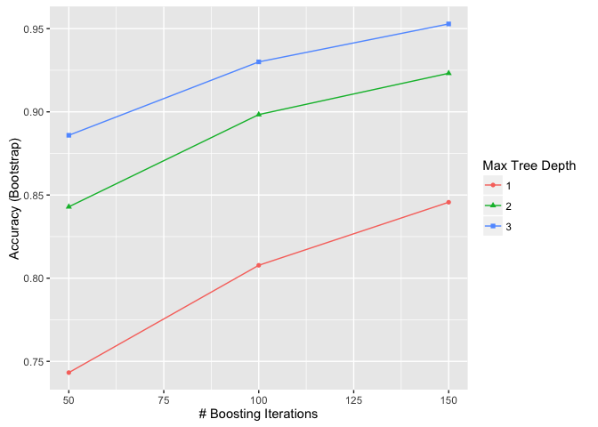

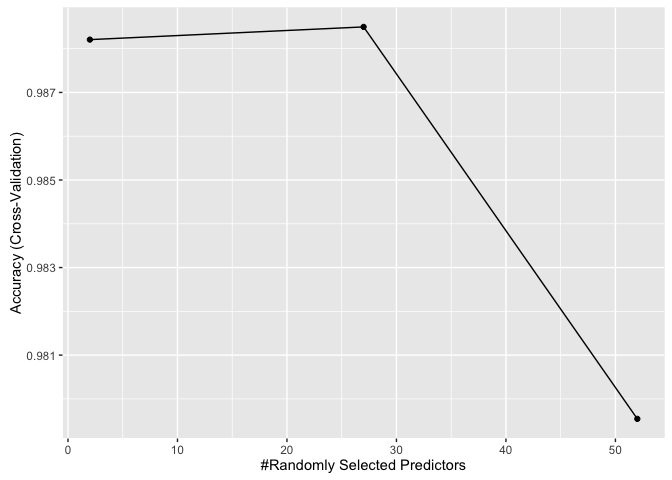

## Prediction and Output

In this section, we use the model that we selected in the last section to predict the test data. After comparing with the correct results, we observe that our model gives **99.37** Accuracy.

```r
fitmodel <- model5

test$classe <- predict(fitmodel, newdata = test)
testPred <- test$classe
```

The predictions for the test data set for each problem id are as below

```r
  dt_res <- data.frame(problem_id = test$problem_id,
             classe = test$classe)

  dt_res
```

```
##    problem_id classe
## 1           1      B
## 2           2      A
## 3           3      B
## 4           4      A
## 5           5      A
## 6           6      E
## 7           7      D
## 8           8      B
## 9           9      A
## 10         10      A
## 11         11      B
## 12         12      C
## 13         13      B
## 14         14      A
## 15         15      E
## 16         16      E
## 17         17      A
## 18         18      B
## 19         19      B
## 20         20      B
```

## References

1: http://groupware.les.inf.puc-rio.br/har#ixzz4FgelrRFy “Human Activity Recognition”